# Coursera course project Machine Learning: Human Activity Regognition

Skrisko

11 juillet 2019

## Introduction

Due to recent techonlogical evolution it is now possible to colect large amout of data with wearable sensor. In this project data from accelerometes on the belt, forearm, and dumbell of 6 participants will be used. The participant were asked to perform barell lifts correctly and incorrectly in 5 different ways. The aim is to find a machine learning algorithm that will classified the differents a testing set into this categories based on the data from the sensors. You can find more data here: <http://web.archive.org/web/20161224072740/http:/groupware.les.inf.puc-rio.br/har >

## Set up

First we will load the different library and the data. We don’t show the console for loading the library.

We download the data.

```r
adresseTrain <- "https://d396qusza40orc.cloudfront.net/predmachlearn/pml-training.csv"
adresseTest <- "https://d396qusza40orc.cloudfront.net/predmachlearn/pml-testing.csv"

## setwd("R/CourseProject8")
training <- read.csv("pml-training.csv")
testing <- read.csv("pml-testing.csv")
```

## Exploratory Data Analysis

We can start with a quick overview of the data. do have a quick overview of the data.

```r
head(training, n=3)
```

```
##   X user_name raw_timestamp_part_1 raw_timestamp_part_2   cvtd_timestamp
## 1 1  carlitos           1323084231               788290 05/12/2011 11:23
## 2 2  carlitos           1323084231               808298 05/12/2011 11:23
## 3 3  carlitos           1323084231               820366 05/12/2011 11:23
##   new_window num_window roll_belt pitch_belt yaw_belt total_accel_belt
## 1         no         11      1.41       8.07    -94.4                3
## 2         no         11      1.41       8.07    -94.4                3
## 3         no         11      1.42       8.07    -94.4                3
##   kurtosis_roll_belt kurtosis_picth_belt kurtosis_yaw_belt
## 1
## 2
## 3
##   skewness_roll_belt skewness_roll_belt.1 skewness_yaw_belt max_roll_belt
## 1                                                                      NA
## 2                                                                      NA
## 3                                                                      NA
##   max_picth_belt max_yaw_belt min_roll_belt min_pitch_belt min_yaw_belt
## 1             NA                         NA             NA
## 2             NA                         NA             NA
## 3             NA                         NA             NA
##   amplitude_roll_belt amplitude_pitch_belt amplitude_yaw_belt
## 1                  NA                   NA
## 2                  NA                   NA
## 3                  NA                   NA
##   var_total_accel_belt avg_roll_belt stddev_roll_belt var_roll_belt
## 1                   NA            NA               NA            NA
## 2                   NA            NA               NA            NA
## 3                   NA            NA               NA            NA
##   avg_pitch_belt stddev_pitch_belt var_pitch_belt avg_yaw_belt
## 1             NA                NA             NA           NA
## 2             NA                NA             NA           NA
## 3             NA                NA             NA           NA
##   stddev_yaw_belt var_yaw_belt gyros_belt_x gyros_belt_y gyros_belt_z
## 1              NA           NA         0.00            0        -0.02
## 2              NA           NA         0.02            0        -0.02
## 3              NA           NA         0.00            0        -0.02
##   accel_belt_x accel_belt_y accel_belt_z magnet_belt_x magnet_belt_y
## 1          -21            4           22            -3           599
## 2          -22            4           22            -7           608
## 3          -20            5           23            -2           600
```

[output cut: 105 more lines]

```
## 1                   NA                NA              NA
## 2                   NA                NA              NA
## 3                   NA                NA              NA
##   stddev_yaw_forearm var_yaw_forearm gyros_forearm_x gyros_forearm_y
## 1                 NA              NA            0.03            0.00
## 2                 NA              NA            0.02            0.00
## 3                 NA              NA            0.03           -0.02
##   gyros_forearm_z accel_forearm_x accel_forearm_y accel_forearm_z
## 1           -0.02             192             203            -215
## 2           -0.02             192             203            -216
## 3            0.00             196             204            -213
##   magnet_forearm_x magnet_forearm_y magnet_forearm_z classe
## 1              -17              654              476      A
## 2              -18              661              473      A
## 3              -18              658              469      A
```

## Sorting the data

Like we see it during the course the first step is to clean the data.

We start by removing the user, name, the date as we want to identify the activity by the data from sensor and not from the users.

```r
toRemove <- c("X", "user_name", "raw_timestamp_part_1", "raw_timestamp_part_2", "cvtd_timestamp", "new_window")
training <- select(training , -toRemove)
```

We can see that there is column with a lot of NA, and we dont want to make a prediction based on predictor that are the most of the time NA. We remove column where there is the most of the time blank or NA.

```r
NotComplet <- apply(training, MARGIN = 2, FUN = function(x) sum(is.na(x)))
training <- training[, names(NotComplet[NotComplet < 100])]

Blank <- apply(training, MARGIN = 2, FUN = function(x) sum(x==""))
training <- training[, names(Blank[Blank<100])]
```

We do the same for the testing set. But keep the problem id as there is no classe specified for the testing set.

```r
testing <- select(testing, names(training[0:53]), "problem_id")
```

## The model

We don’t want to overfit the model, and to test our model we need a set of data where the classe are given. Therefore we split the training data into two sub groupe. subTraining and subTesting. The methode is given in the slide of the first week of course and we respect the ration 3/4 for the remaining training data and 1/4 for the testing data.

Then we do the preprocessing to avoir biais we center and scale the data. And then we put in place a control for the training function based on a repeated cross validation.It split the data each time and give a more robust model. It is a way to increase in our case the accuracy.

```r
set.seed(253)
inTrain = createDataPartition(training$classe, p = 3/4)[[1]]
subTraining = training[ inTrain,]
subTesting = training[-inTrain,]
preProc <- c("center", "scale")

control <- trainControl(method="repeatedcv", number =3, repeats = 2)
```

## Training the model

We don’t incude the result of the R console because it is to long.

We store our model in modFit like during the course. We train the model on all predictor. Based on the subset of the training set. We specify our preprocessing and our control. The methode choosen is the gradient bossting model.

```r
modFit <- train(classe~., method = "gbm", data = subTraining, metric= "Accuracy", preProcess = preProc, trControl = control)
```

## The analyze of the classifier

We print the model that was selected and the result of the accuracy at each step of the process. We plot the model to see the evolution of it.

```r
print(modFit)
```

```
## Stochastic Gradient Boosting
##
## 14718 samples
##    53 predictor
##     5 classes: 'A', 'B', 'C', 'D', 'E'
##
## Pre-processing: centered (53), scaled (53)
## Resampling: Cross-Validated (3 fold, repeated 2 times)
## Summary of sample sizes: 9812, 9811, 9813, 9812, 9812, 9812, ...
## Resampling results across tuning parameters:
##
##   interaction.depth  n.trees  Accuracy   Kappa
##   1                   50      0.7551975  0.6894080
##   1                  100      0.8295625  0.7841787
##   1                  150      0.8701248  0.8356122
##   2                   50      0.8835097  0.8525057
##   2                  100      0.9411945  0.9255967
##   2                  150      0.9641597  0.9546566
##   3                   50      0.9322258  0.9142069
##   3                  100      0.9708859  0.9631678
##   3                  150      0.9848146  0.9807906
##
## Tuning parameter 'shrinkage' was held constant at a value of 0.1
##
## Tuning parameter 'n.minobsinnode' was held constant at a value of 10
## Accuracy was used to select the optimal model using the largest value.
## The final values used for the model were n.trees = 150,
##  interaction.depth = 3, shrinkage = 0.1 and n.minobsinnode = 10.
```

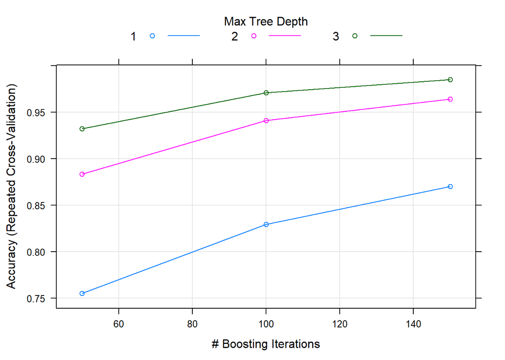

```r
plot(modFit)
```

## The prediction on the first testing set

We can now see the result on the testing set that come from the original training set. We see that there is only few error and the accuracy is quite good. The classe C is the one that have the worst result but still very good.

```r
pred <- predict(modFit, subTesting)
confusionMatrix(subTesting$classe, pred)
```

```
## Confusion Matrix and Statistics
##
##           Reference
## Prediction    A    B    C    D    E
##          A 1393    2    0    0    0
##          B    4  932   13    0    0
##          C    0    4  850    1    0
##          D    0   10   12  780    2
##          E    0    0    0   12  889
##
## Overall Statistics
##
##                Accuracy : 0.9878
##                  95% CI : (0.9843, 0.9907)
##     No Information Rate : 0.2849
##     P-Value [Acc > NIR] : < 2.2e-16
##
##                   Kappa : 0.9845
##
##  Mcnemar's Test P-Value : NA
##
## Statistics by Class:
##
##                      Class: A Class: B Class: C Class: D Class: E
## Sensitivity            0.9971   0.9831   0.9714   0.9836   0.9978
## Specificity            0.9994   0.9957   0.9988   0.9942   0.9970
## Pos Pred Value         0.9986   0.9821   0.9942   0.9701   0.9867
## Neg Pred Value         0.9989   0.9960   0.9938   0.9968   0.9995
## Prevalence             0.2849   0.1933   0.1784   0.1617   0.1817
## Detection Rate         0.2841   0.1900   0.1733   0.1591   0.1813
## Detection Prevalence   0.2845   0.1935   0.1743   0.1639   0.1837
## Balanced Accuracy      0.9983   0.9894   0.9851   0.9889   0.9974
```

## Final testing on the real testing set

We can do the final testing on the where we don’t know the classe of but we only have the problem id.

```r
predFinal <- predict(modFit, testing)
summary(predFinal)
```

```
## A B C D E
## 7 8 1 1 3
```

## Conclusion

We have use what we have learn during the 4 week of machine learning course. We have start with raw data, we have clean it. Then we have prepare our analyse with a training set a validation set and a testing set to avoir overfitting. After this we have build the the training function with a control and a preprocessing of the data. We have analyze the predictor and then the accuracy with the validation set. ANd finaly we have applied it to the testing set. With this exercice we went through all the step of a machine learning problem. And try to use all the technique we see during the course.